# Tidy Data - with packages *tibble* / *tidyr* / *dplyr*

Journey into the Tidyverse

*Wolfgang Vollmer*

January 31, 2018

# Content & Objectives

- **Presentation will provide**
  - Short ‘theoretical’ consideration of tidy data
  - Providing simple ‘messy’ example data set
  - Tidying ‘messy’ example data set by basic functions of ‘tibble’, ‘tidir’ and ‘dplyr’ package
  - Provides some ‘basic’ examples of data set manipulation/evaluation by dplyr functions
- **Basic understanding** should be transmitted by the presentation
  - should be a good starting point for digging deeper
- **Presentation will not provide**
  - complete overview of all available functions
  - detailed descriptions of functions
- **Detailed information** is given by package vignettes, package index, help functions and references

# Short ‘theoretical’ consideration of tidy data

## Tidy Data - What does tidy data mean ?

For detailed descriptions see

- [*Hadley Wickham - Tidy Data*](https://www.jstatsoft.org/article/view/v059i10) Journal of Statistical Software

**Importance of Data Tidying:**

- **data tidying:** structuring datasets to facilitate analysis
  - often said: 80% of data analysis is spent on the cleaning and preparing data

**Statistical datasets are mostly:**

- datasets / data frames made up of rows and columns
  - columns are almost always labeled
  - rows are sometimes labeled

**Tidy Data definition:**

- **tidy data** characteristics:
  - each variable forms a column
  - each observation forms a row
  - each type of observational unit forms a table
- approach fits to [*Database normalization*](https://en.wikipedia.org/wiki/Database_normalization) and [*Codd’s 3NF - Third normal form*](https://en.wikipedia.org/wiki/Third_normal_form)
  - in statistics we have focus on **single dataset** rather than many connected datasets in relational databases

# Simple ‘messy’ example data set

```
##
##
##  Example data from FoRt course
##       public/individual: means of transport
##       time_public/individual: average travel time by means of transport
##       (l/s): (lecturer/student)
```

FoRt - Messy data

|  | sex | age | residence | public | individual | time_public | time_individual | pres_Oct | pres_Nov | pres_Dec |
| --- | --- | --- | --- | --- | --- | --- | --- | --- | --- | --- |
| Fabian Scheipl (l) | m | 30 - 40 | P. | y | y | 60 | 50 | 3 | 4 | 2 |
| Vollmer, Wolfgang (s) | m | >20 | Munich | y | y | 30 | 45 | 2 | 4 | 2 |
| Erika Musterfrau (s) | f | 25 | Muenchen | y | n | 45 | NA | 3 | 3 | 1 |
| Liz Morrison (s) | f | unknown | München | n | y | NA | 10 | 3 | 2 | 2 |

```
##
##
##  Same data 'values' but transposed by t() => 'only' different layout
##      'variables' and 'observation' are switched
```

FoRt - Messy data - data transposed

|  | Fabian Scheipl (l) | Vollmer, Wolfgang (s) | Erika Musterfrau (s) | Liz Morrison (s) |
| --- | --- | --- | --- | --- |
| sex | m | m | f | f |
| age | 30 - 40 | >20 | 25 | unknown |
| residence | P. | Munich | Muenchen | München |
| public | y | y | y | n |
| individual | y | y | n | y |
| time_public | 60 | 30 | 45 | NA |
| time_individual | 50 | 45 | NA | 10 |
| pres_Oct | 3 | 2 | 3 | 3 |
| pres_Nov | 4 | 4 | 3 | 2 |
| pres_Dec | 2 | 2 | 1 | 2 |

```
##
##
##  Manual value clean up of row.names (structure), birthday (values) and residence (typing)
```

FoRt - Messy data, manualy cleaned up *)

|  | birthday | residence | sex | public | individual | time_public | time_individual | pres_Oct | pres_Nov | pres_Dec |
| --- | --- | --- | --- | --- | --- | --- | --- | --- | --- | --- |
| Fabian Scheipl (l) | 1947-08-13 | P. | m | y | y | 60 | 50 | 3 | 4 | 2 |
| Wolfgang Vollmer (s) | 1824-02-23 | Munich | m | y | y | 30 | 45 | 2 | 4 | 2 |
| Erika Musterfrau (s) | 2002-11-23 | Munich | f | y | n | 45 | NA | 3 | 3 | 1 |
| Liz Morrison (s) | NA | Munich | f | n | y | NA | 10 | 3 | 2 | 2 |

*) birthday is encrypted by [*Scheipl et al., 2015, Identifiability in penalized birthday encryption algorithm*](https://www.researchgate.net/publication/278048180_Identifiability_in_penalized_function-on-function_regression_models)

**Check of Tidy Data Conditions:**

```
##
##
##  Tidy data are data where:
##
##       Each variable is in a column
##           => not given for values of row.names, not a column
##              and in addition name and role are mixed up
##              even name must be split, if 'first name' and 'surname' are for interest
##           => redundant information e.g. public / time_public
##           => not given for variable transport = public/individual
##           => not given for variable month = Oct/Nov/Dec
##
##       Each observation is a row
##           => not given for different observations in e.g. month = Oct/Nov/Dec
##
##       Each type of observational unit forms a table
##           => not given, general transport variables are mixed with monthly data (violating 2. NF)
```

# Tidying ‘messy’ example data set

**Tidying by basic functions of ‘tibble’, ‘tidyr’ and ‘dplyr’ package**

common loading by library(tidyverse)

```r
# browseVignettes(package = c("tibble", "tidyr", "dplyr", "magrittr"))
# install.packages("tidyverse")

library(tidyverse)
```

**== Backup - tidyverse packages =============================================**

```r
tidyverse_logo()
```

```
## * __  _    __   .    o           *  .
##  / /_(_)__/ /_ ___  _____ _______ ___
## / __/ / _  / // / |/ / -_) __(_-</ -_)
## \__/_/\_,_/\_, /|___/\__/_/ /___/\__/
##      *  . /___/      o      .       *
```

```r
# "tibble" -  modern re-imagining of the data frame
#             tibbles are lazy and surly: they do less and complain more

# "tidyr" - set of functions that help you get to tidy data
#           e.g. gather/spread function, change dataframe wide/long form
#                       instead melt, dcast function from reshape2
#                       similar to pivot tables in spreadsheets

# "dplyr" - grammar of data manipulation, providing a consistent set of verbs
#           that solve the most common data manipulation challenges
#           e.g. mutate, filter function
#           replaces plyr (but no ddply function, if still needed plyr to be loaded first),
#           dplyr is much faster (up to 1000x) as plyr
#
#     remarks:
#           "magrittr" package is loaded by dplyr
#                 provides chaining commands with forward-pipe operator '%>%'
#           "data.table" is an alternative ("competing") package for "dplyr"

# "readr" - fast and friendly way to read rectangular data (like csv, tsv, and fwf)


# "ggplot2" - creating graphics, based on "The Grammar of Graphics"

# "purr"    - enhances R’s functional programming (FP) toolkit


#  five packages designed to work with specific types of data:
#   "stringr" for strings.
#   "lubridate" for dates and date-times.
#   "forcats" for categorical variables (factors).
#   "hms" for time-of-day values.
#   "blob" for storing blob (binary) data.


suppressMessages(library(gridExtra))  # Miscellaneous Functions for "Grid" Graphics
```

## tibble data frame

- coerce data frames in a tibble and “save” rownames as variable

```r
#
#
# tibble: modern take on data frames
#  - keep the features that have stood the test of time
#  - drop the features that used to be convenient but are now frustrating
#    it never changes an input’s type i.e. converting character vectors to factors
#  - it never adjusts the names of variables (data.frame: "crazy name" => "crazy.name")
#  - It never uses row.names(), it never stores a variable as special attribute
# -  Recycling: when constructing a tibble, only values of length 1 are recycled

# example for tibble generation (class: "tbl_df", "tbl", "data.frame" )
tibble(x = 1:5, "crazy name" = x ^ 2, C = "new") # evaluates its arguments lazily and sequentially
```

```
## # A tibble: 5 x 3
##       x `crazy name` C
##   <int>        <dbl> <chr>
## 1     1         1.00 new
## 2     2         4.00 new
## 3     3         9.00 new
## 4     4        16.0  new
## 5     5        25.0  new
```

```r
# data.frame(x = 1:5, y = x ^ 2) => throws Error: object 'x' not found

#
#
# coerce data.frame in a tibble with as.tibble
# Attention: tibble data frame does not have row_names !!
##                                        => use rownames_to_column()


(fort_data_tbl <- as_tibble(rownames_to_column(fort_data_df, var = "name")))
```

```
## # A tibble: 4 x 11
##   name    birth~ resid~ sex    public indi~ time~ time_~ pres~ pres~ pres~
##   <chr>   <fctr> <fctr> <fctr> <fctr> <fct> <dbl>  <dbl> <dbl> <dbl> <dbl>
## 1 Fabian~ 1947-~ P.     m      y      y      60.0   50.0  3.00  4.00  2.00
## 2 Wolfga~ 1824-~ Munich m      y      y      30.0   45.0  2.00  4.00  2.00
## 3 Erika ~ 2002-~ Munich f      y      n      45.0   NA    3.00  3.00  1.00
## 4 Liz Mo~ <NA>   Munich f      n      y      NA     10.0  3.00  2.00  2.00
```

## Variables (columns) and Observations/Cases (rows) tidying by tidyr / dplyr functions

**Each variable forms a column**

- **Separate** “multiple variable” column in separate columns
- **Select** out / delete columns with “redundant” information
- **“Piping”** with *pipe operator* `%>%` makes code simple to read

```r
#
#
# "tidyr" - gather/spread function, change data frame wide/long form
#           seperate / unite / extract function
#
# "dplyr" - grammar of data manipulation
#           mutate/transmute/rename,  filter/select, arrange function
#           group_by
#
#
# separate(): separates single character column into multiple columns
# select():   selects the variables/columns
#             Positive values select variables; negative values drop variables


fort_data_tbl_update <-
   fort_data_tbl %>%                 # pipe operator ("then")
   separate(name, c("name", "role"),
            sep = "[[:punct:]{,1}]", extra = "drop") %>%
   select(-public, -individual)
```

First tidying steps - name and role separated, columns public / individual deleted

| name | role | birthday | residence | sex | time_public | time_individual | pres_Oct | pres_Nov | pres_Dec |
| --- | --- | --- | --- | --- | --- | --- | --- | --- | --- |
| Fabian Scheipl | l | 1947-08-13 | P. | m | 60 | 50 | 3 | 4 | 2 |
| Wolfgang Vollmer | s | 1824-02-23 | Munich | m | 30 | 45 | 2 | 4 | 2 |
| Erika Musterfrau | s | 2002-11-23 | Munich | f | 45 | NA | 3 | 3 | 1 |
| Liz Morrison | s | NA | Munich | f | NA | 10 | 3 | 2 | 2 |

### Each type of observational unit forms a table

- **Split table** according observational unit to
  - FoRt person’s “general” data
  - FoRt person’s “monthly” dependent data
  - common key: “name”

### Each observation is a row

- **Gather data** from *wide* to *long form*
  - “general” data: observations on person and transport mode level
  - “motnhly” data: observations on person and monthly level

```r
#
#
# gather():   gather/melt multiple columns into rows, converts data from wide
#             form to long form
#             key:   variable name of new variable created for the gathered column names
#             value: variable name of new variable created from the cell values
#                    of gathered columns
#             ...:   specifying range of variables/columns to be gathered,
#                    default: all variables are selected, negative values for dropping
# mutate():   compute new column(s)
# arrange():  order rows by values of a column (low to high)
# rename():   renames column(s)


fort_general_data_tbl <-
    fort_data_tbl_update %>%
    select(name, birthday, sex, residence, role, time_public, time_individual) %>%
    gather(key = transport_mode, value = "avg_travel_time",
           time_public:time_individual) %>%
    mutate(transport_mode = gsub("time_", "", transport_mode)) %>%
    #  replaces in new column 'transport_mode'
    #     time_public/_indiviudal by public/individual
    arrange(name, transport_mode)
    # sort by name and then by transport_mode

# note: columns are ordered with ordering within select()
#       rule: fixed values come first, followed by measured variables
```

Tidy general data

| name | birthday | sex | residence | role | transport_mode | avg_travel_time |
| --- | --- | --- | --- | --- | --- | --- |
| Erika Musterfrau | 2002-11-23 | f | Munich | s | individual | NA |
| Erika Musterfrau | 2002-11-23 | f | Munich | s | public | 45 |
| Fabian Scheipl | 1947-08-13 | m | P. | l | individual | 50 |
| Fabian Scheipl | 1947-08-13 | m | P. | l | public | 60 |
| Liz Morrison | NA | f | Munich | s | individual | 10 |
| Liz Morrison | NA | f | Munich | s | public | NA |
| Wolfgang Vollmer | 1824-02-23 | m | Munich | s | individual | 45 |
| Wolfgang Vollmer | 1824-02-23 | m | Munich | s | public | 30 |

```r
fort_monthly_data_tbl <-
    fort_data_tbl_update %>%
    select(name, pres_Oct:pres_Dec) %>%
    rename("2017-10" = "pres_Oct", "2017-11" = "pres_Nov", "2017-12" = "pres_Dec")  %>%
    gather(key = month, value = "presence",
           "2017-10":"2017-12") %>%
    # gather multiple columns (default: all variables are selected) into rows
    # converts data from wide form to long form (gather ~ melt function)
    arrange(name, month)
    # sort by name and then by month
```

Tidy monthly data

| name | month | presence |
| --- | --- | --- |
| Erika Musterfrau | 2017-10 | 3 |
| Erika Musterfrau | 2017-11 | 3 |
| Erika Musterfrau | 2017-12 | 1 |
| Fabian Scheipl | 2017-10 | 3 |
| Fabian Scheipl | 2017-11 | 4 |
| Fabian Scheipl | 2017-12 | 2 |
| Liz Morrison | 2017-10 | 3 |
| Liz Morrison | 2017-11 | 2 |
| Liz Morrison | 2017-12 | 2 |
| Wolfgang Vollmer | 2017-10 | 2 |
| Wolfgang Vollmer | 2017-11 | 4 |
| Wolfgang Vollmer | 2017-12 | 2 |

**== Backup - long / wide form - back and forth circle =======================**

```r
## long / wide form - back and forth circle ----------------------------
# spread() (from long to wide form / 'cast' function)
# gather() (from long to wide form / 'melt' function)

fort_general_data_tbl  # already 'gathered' data (long form)
```

```
## # A tibble: 8 x 7
##   name                birthday   sex    residence role  transpor~ avg_tra~
##   <chr>               <fctr>     <fctr> <fctr>    <chr> <chr>        <dbl>
## 1 "Erika Musterfrau " 2002-11-23 f      Munich    s     individu~     NA
## 2 "Erika Musterfrau " 2002-11-23 f      Munich    s     public        45.0
## 3 "Fabian Scheipl "   1947-08-13 m      P.        l     individu~     50.0
## 4 "Fabian Scheipl "   1947-08-13 m      P.        l     public        60.0
## 5 "Liz Morrison "     <NA>       f      Munich    s     individu~     10.0
## 6 "Liz Morrison "     <NA>       f      Munich    s     public        NA
## 7 "Wolfgang Vollmer " 1824-02-23 m      Munich    s     individu~     45.0
## 8 "Wolfgang Vollmer " 1824-02-23 m      Munich    s     public        30.0
```

```r
(fort_general_data_tbl_wide <-
    spread(fort_general_data_tbl,       # from long to wide form
      key = transport_mode, value = avg_travel_time) %>%
    rename("time_public" = "public", "time_individual" = "individual"))
```

```
## # A tibble: 4 x 7
##   name                birthday   sex    residence role  time_indi~ time_p~
## * <chr>               <fctr>     <fctr> <fctr>    <chr>      <dbl>   <dbl>
## 1 "Erika Musterfrau " 2002-11-23 f      Munich    s           NA      45.0
## 2 "Fabian Scheipl "   1947-08-13 m      P.        l           50.0    60.0
## 3 "Liz Morrison "     <NA>       f      Munich    s           10.0    NA
## 4 "Wolfgang Vollmer " 1824-02-23 m      Munich    s           45.0    30.0
```

```r
(fort_general_data_tbl_long <-
    fort_general_data_tbl_wide %>%      # from wide to long form
    rename("public" = "time_public", "individual" = "time_individual") %>%
    gather(key = transport_mode, value = avg_travel_time, public:individual) %>%
    arrange(name, avg_travel_time))
```

```
## # A tibble: 8 x 7
##   name                birthday   sex    residence role  transpor~ avg_tra~
##   <chr>               <fctr>     <fctr> <fctr>    <chr> <chr>        <dbl>
## 1 "Erika Musterfrau " 2002-11-23 f      Munich    s     public        45.0
## 2 "Erika Musterfrau " 2002-11-23 f      Munich    s     individu~     NA
## 3 "Fabian Scheipl "   1947-08-13 m      P.        l     individu~     50.0
## 4 "Fabian Scheipl "   1947-08-13 m      P.        l     public        60.0
## 5 "Liz Morrison "     <NA>       f      Munich    s     individu~     10.0
## 6 "Liz Morrison "     <NA>       f      Munich    s     public        NA
## 7 "Wolfgang Vollmer " 1824-02-23 m      Munich    s     public        30.0
## 8 "Wolfgang Vollmer " 1824-02-23 m      Munich    s     individu~     45.0
```

```r
identical(fort_general_data_tbl, fort_general_data_tbl_long)
```

```
## [1] FALSE
```

## Plot - tidy data are easy to visualize with ggplot2

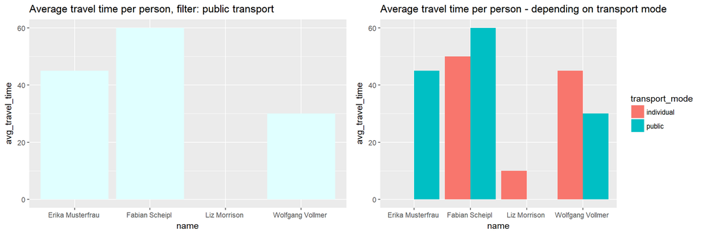

```r
#
#
# filter():   filters rows/cases where conditions are true

grid.arrange(
  ggplot(filter(fort_general_data_tbl, transport_mode == "public"), aes(name, avg_travel_time)) +
    geom_bar(stat = 'identity', fill = "lightcyan", na.rm = TRUE) +
    ggtitle("Average travel time per person, filter: public transport"),

  ggplot(fort_general_data_tbl, aes(name, avg_travel_time, fill = transport_mode)) +
    geom_bar(stat = 'identity', position = "dodge", na.rm = TRUE) +
    ggtitle("Average travel time per person - depending on transport mode"),
  ncol=2)
```

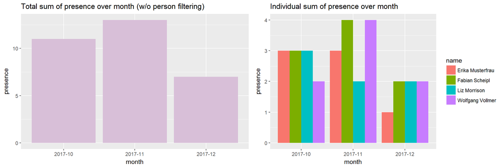

```r
grid.arrange(
  ggplot(fort_monthly_data_tbl, aes(month, presence)) +
    geom_bar(stat = 'identity', fill = "thistle", na.rm = TRUE) +
    ggtitle("Total sum of presence over month (w/o person filtering)"),

  ggplot(fort_monthly_data_tbl, aes(month, presence, fill = name)) +
    geom_bar(stat = 'identity', position = "dodge", na.rm = TRUE) +
    ggtitle("Individual sum of presence over month"),
  ncol=2)
```

# Some ‘basic’ data manipulation examples with data set *mtcars*

**Grouping:** dplyr functions will manipulate each “group” separately and then combine the results

**Summariy functions:** take vectors as input and return single values as output

```r
# mtcars_df: mtcars with rownames and reduced variables, but still data.frame
mtcars_df <- mtcars %>%                      # note: mtcars_df still no tibble
  rownames_to_column(var = "model") %>%      # w/ rownames
  select(model:hp, am)                       # reduce number of variables


mtcars_df %>%
  group_by(cyl, am) %>%      # grouping first by cyl, then by am
  # creates a "grouped" copy of a table. dplyr functions will manipulate
  # each "group" separately and then combine the results
  summarise(cases = n(),
            mean_mpg = mean(mpg),
            mean_hp = mean(hp)) %>%
  # summarize: take vectors as input and return single values as output
  # grouped data: output will have one row for each group
  mutate(ratio_hp_mpg = mean_mpg / mean_hp) %>%
  # Compute new column(s)
  arrange(mean_hp)
```

```
## # A tibble: 6 x 6
## # Groups: cyl [3]
##     cyl    am cases mean_mpg mean_hp ratio_hp_mpg
##   <dbl> <dbl> <int>    <dbl>   <dbl>        <dbl>
## 1  4.00  1.00     8     28.1    81.9       0.343
## 2  4.00  0        3     22.9    84.7       0.270
## 3  6.00  0        4     19.1   115         0.166
## 4  6.00  1.00     3     20.6   132         0.156
## 5  8.00  0       12     15.0   194         0.0775
## 6  8.00  1.00     2     15.4   300         0.0514
```

```r
# Order rows by values of a column (low to high)



mtcars_df %>%
  group_by(cyl) %>%        # grouping by cyl
  summarise(cases = n(),   # reduces number of rows to number of groups
            mean_mpg = mean(mpg),
            mean_hp = mean(hp)) %>%
  ungroup() %>%      # ungrouping for transmute function
  transmute(ratio_hp_mpg = mean_mpg / mean_hp) %>%
  # Compute new column(s), drop's all others
  arrange(ratio_hp_mpg)
```

```
## # A tibble: 3 x 1
##   ratio_hp_mpg
##          <dbl>
## 1       0.0722
## 2       0.161
## 3       0.323
```

**Vectorized functions:** take vectors as input and return vectors of the same length as output

```r
#
#
# be carefull with storing grouped data <- will remain grouped
# use ungroup() if grouping not needed

(mtcars_df_still_grouped <-
   mtcars_df %>%
   group_by(cyl) %>%
   mutate(number_1 = row_number()))
```

```
## # A tibble: 32 x 7
## # Groups: cyl [3]
##    model               mpg   cyl  disp    hp    am number_1
##    <chr>             <dbl> <dbl> <dbl> <dbl> <dbl>    <int>
##  1 Mazda RX4          21.0  6.00   160 110    1.00        1
##  2 Mazda RX4 Wag      21.0  6.00   160 110    1.00        2
##  3 Datsun 710         22.8  4.00   108  93.0  1.00        1
##  4 Hornet 4 Drive     21.4  6.00   258 110    0           3
##  5 Hornet Sportabout  18.7  8.00   360 175    0           1
##  6 Valiant            18.1  6.00   225 105    0           4
##  7 Duster 360         14.3  8.00   360 245    0           2
##  8 Merc 240D          24.4  4.00   147  62.0  0           2
##  9 Merc 230           22.8  4.00   141  95.0  0           3
## 10 Merc 280           19.2  6.00   168 123    0           5
## # ... with 22 more rows
```

```r
mtcars_df_still_grouped %>% mutate(number_1b = row_number())
```

```
## # A tibble: 32 x 8
## # Groups: cyl [3]
##    model               mpg   cyl  disp    hp    am number_1 number_1b
##    <chr>             <dbl> <dbl> <dbl> <dbl> <dbl>    <int>     <int>
##  1 Mazda RX4          21.0  6.00   160 110    1.00        1         1
##  2 Mazda RX4 Wag      21.0  6.00   160 110    1.00        2         2
##  3 Datsun 710         22.8  4.00   108  93.0  1.00        1         1
##  4 Hornet 4 Drive     21.4  6.00   258 110    0           3         3
##  5 Hornet Sportabout  18.7  8.00   360 175    0           1         1
##  6 Valiant            18.1  6.00   225 105    0           4         4
##  7 Duster 360         14.3  8.00   360 245    0           2         2
##  8 Merc 240D          24.4  4.00   147  62.0  0           2         2
##  9 Merc 230           22.8  4.00   141  95.0  0           3         3
## 10 Merc 280           19.2  6.00   168 123    0           5         5
## # ... with 22 more rows
```

```r
# same as number_1 since still grouped

(mtcars_df_ungrouped <-
    mtcars_df %>%
    group_by(cyl) %>%
    mutate(number_2 = row_number()) %>%
    ungroup())
```

```
## # A tibble: 32 x 7
##    model               mpg   cyl  disp    hp    am number_2
##    <chr>             <dbl> <dbl> <dbl> <dbl> <dbl>    <int>
##  1 Mazda RX4          21.0  6.00   160 110    1.00        1
##  2 Mazda RX4 Wag      21.0  6.00   160 110    1.00        2
##  3 Datsun 710         22.8  4.00   108  93.0  1.00        1
##  4 Hornet 4 Drive     21.4  6.00   258 110    0           3
##  5 Hornet Sportabout  18.7  8.00   360 175    0           1
##  6 Valiant            18.1  6.00   225 105    0           4
##  7 Duster 360         14.3  8.00   360 245    0           2
##  8 Merc 240D          24.4  4.00   147  62.0  0           2
##  9 Merc 230           22.8  4.00   141  95.0  0           3
## 10 Merc 280           19.2  6.00   168 123    0           5
## # ... with 22 more rows
```

```r
mtcars_df_ungrouped %>% mutate(number_2b = row_number())
```

```
## # A tibble: 32 x 8
##    model               mpg   cyl  disp    hp    am number_2 number_2b
##    <chr>             <dbl> <dbl> <dbl> <dbl> <dbl>    <int>     <int>
##  1 Mazda RX4          21.0  6.00   160 110    1.00        1         1
##  2 Mazda RX4 Wag      21.0  6.00   160 110    1.00        2         2
##  3 Datsun 710         22.8  4.00   108  93.0  1.00        1         3
##  4 Hornet 4 Drive     21.4  6.00   258 110    0           3         4
##  5 Hornet Sportabout  18.7  8.00   360 175    0           1         5
##  6 Valiant            18.1  6.00   225 105    0           4         6
##  7 Duster 360         14.3  8.00   360 245    0           2         7
##  8 Merc 240D          24.4  4.00   147  62.0  0           2         8
##  9 Merc 230           22.8  4.00   141  95.0  0           3         9
## 10 Merc 280           19.2  6.00   168 123    0           5        10
## # ... with 22 more rows
```

```r
# different to number_2 since running over ungrouped table
```

**Combine Tables:** Variables and Rows

```r
#
#
# Combine rows with bind_rows
# Combine Variables with bind_cols() or "Mutating Join"
# use ungroup() if grouping not needed

bind_rows(mtcars_df_still_grouped, mtcars_df_ungrouped)
```

```
## # A tibble: 64 x 8
## # Groups: cyl [3]
##    model               mpg   cyl  disp    hp    am number_1 number_2
##    <chr>             <dbl> <dbl> <dbl> <dbl> <dbl>    <int>    <int>
##  1 Mazda RX4          21.0  6.00   160 110    1.00        1       NA
##  2 Mazda RX4 Wag      21.0  6.00   160 110    1.00        2       NA
##  3 Datsun 710         22.8  4.00   108  93.0  1.00        1       NA
##  4 Hornet 4 Drive     21.4  6.00   258 110    0           3       NA
##  5 Hornet Sportabout  18.7  8.00   360 175    0           1       NA
##  6 Valiant            18.1  6.00   225 105    0           4       NA
##  7 Duster 360         14.3  8.00   360 245    0           2       NA
##  8 Merc 240D          24.4  4.00   147  62.0  0           2       NA
##  9 Merc 230           22.8  4.00   141  95.0  0           3       NA
## 10 Merc 280           19.2  6.00   168 123    0           5       NA
## # ... with 54 more rows
```

```r
# Paste tables below each other as they are

bind_cols(mtcars_df_still_grouped, mtcars_df_ungrouped)
```

```
## # A tibble: 32 x 14
## # Groups: cyl [3]
##    model   mpg   cyl  disp    hp    am numb~ mode~  mpg1  cyl1 disp1   hp1
##    <chr> <dbl> <dbl> <dbl> <dbl> <dbl> <int> <chr> <dbl> <dbl> <dbl> <dbl>
##  1 Mazd~  21.0  6.00   160 110    1.00     1 Mazd~  21.0  6.00   160 110
##  2 Mazd~  21.0  6.00   160 110    1.00     2 Mazd~  21.0  6.00   160 110
##  3 Dats~  22.8  4.00   108  93.0  1.00     1 Dats~  22.8  4.00   108  93.0
##  4 Horn~  21.4  6.00   258 110    0        3 Horn~  21.4  6.00   258 110
##  5 Horn~  18.7  8.00   360 175    0        1 Horn~  18.7  8.00   360 175
##  6 Vali~  18.1  6.00   225 105    0        4 Vali~  18.1  6.00   225 105
##  7 Dust~  14.3  8.00   360 245    0        2 Dust~  14.3  8.00   360 245
##  8 Merc~  24.4  4.00   147  62.0  0        2 Merc~  24.4  4.00   147  62.0
##  9 Merc~  22.8  4.00   141  95.0  0        3 Merc~  22.8  4.00   141  95.0
## 10 Merc~  19.2  6.00   168 123    0        5 Merc~  19.2  6.00   168 123
## # ... with 22 more rows, and 2 more variables: am1 <dbl>, number_2 <int>
```

```r
# Returns tables placed side by side as a single table => even "former" rownames are doubled

left_join(mtcars_df_still_grouped, mtcars_df_ungrouped)
```

```
## # A tibble: 32 x 8
## # Groups: cyl [?]
##    model               mpg   cyl  disp    hp    am number_1 number_2
##    <chr>             <dbl> <dbl> <dbl> <dbl> <dbl>    <int>    <int>
##  1 Mazda RX4          21.0  6.00   160 110    1.00        1        1
##  2 Mazda RX4 Wag      21.0  6.00   160 110    1.00        2        2
##  3 Datsun 710         22.8  4.00   108  93.0  1.00        1        1
##  4 Hornet 4 Drive     21.4  6.00   258 110    0           3        3
##  5 Hornet Sportabout  18.7  8.00   360 175    0           1        1
##  6 Valiant            18.1  6.00   225 105    0           4        4
##  7 Duster 360         14.3  8.00   360 245    0           2        2
##  8 Merc 240D          24.4  4.00   147  62.0  0           2        2
##  9 Merc 230           22.8  4.00   141  95.0  0           3        3
## 10 Merc 280           19.2  6.00   168 123    0           5        5
## # ... with 22 more rows
```

```r
# Join matching values from talbe 1 and table 2
```

# References

- [Hadley Wickham, *Tidy Data*, Journal of Statistical Software 2014](https://www.jstatsoft.org/article/view/v059i1)
- [Hadley Wickham, *ggplot2 Elegant Graphics for Data Analysis*, Springer (Second Edition 2016, LMU e-book link)](https://opac.ub.uni-muenchen.de/TouchPoint/singleHit.do?methodToCall=showHit&curPos=4&identifier=2_SOLR_SERVER_779117369)
  - see chapter 9 - Data Analysis & chapter 10 - Data Transformation
- [Hadley Wickham, *Tidyverse - R packages for data science*, Opinionated collection of R packages designed for data science](https://www.tidyverse.org/)
- [*tibble: a modern take on data frames*, cran.r-project.org](https://cran.r-project.org/web/packages/tibble/)
  - tibble() is a nice way to create data frames. It encapsulates best practices for data frames. It never changes an input’s type (i.e., no more stringsAsFactors = FALSE!).
- [*tidyr: Easily Tidy Data with ‘spread()’ and ‘gather()’ Functions*, cran.r-project.org](https://cran.r-project.org/web/packages/tidyr/)
  - An evolution of ‘reshape2’. It’s designed specifically for data tidying (not general reshaping or aggregating) and works well with ‘dplyr’ data pipelines
- [*dplyr: A Grammar of Data Manipulation*, cran.r-project.org](https://cran.r-project.org/web/packages/dplyr/)
  - A fast, consistent tool for working with data frame like objects, both in memory and out of memory
- [*magrittr: A Forward-Pipe Operator for R*, cran.r-project.org](https://cran.r-project.org/web/packages/magrittr/)
  - chaining commands with forward-pipe operator ‘%>%’
- [*RStudio Cheat Sheets*](https://www.rstudio.com/resources/cheatsheets/)

**Additional References**

- [Philipp J. Rösch, *A Grammar of Data Manipulation - Eine Einführung in das Paket dplyr*, Applied R Munich 2015-10-26](https://github.com/lmu-applied-r/2015-dplyr)

*and references from this slide set:*

- Two YouTube Tutorials by Kevin Markhams:
  - [*Tutorial 1*](https://www.youtube.com/watch?v=jWjqLW-u3hc)
  - [*Tutorial 2*](https://www.youtube.com/watch?v=2mh1PqfsXVI)
- [Hadley Wickham, *Webinar über dplyr (and ggvis)*, 2014*](http://pages.rstudio.net/Webinar-Series-Recording-Essential-Tools-for-R.html)
- [Hadley Wickham, *dplyr Tutorial at useR! 2014*](https://www.dropbox.com/sh/i8qnluwmuieicxc/AAAgt9tIKoIm7WZKIyK25lh6a)

== for package ‘data.table’ information see ====================

- [Janek Thomas, *Introduction to data.tables*, Applied R Munich 2016-04-25](https://github.com/lmu-applied-r/2016-data.table)

*and references from this slide set:*

- [*data.table: Extension of ‘data.frame’*, cran.r-project.org](https://cran.r-project.org/web/packages/data.table/)
  - Fast aggregation of large data (e.g. 100GB in RAM), fast ordered joins, fast add/modify/delete of columns by group using no copies at all, list columns, a fast friendly file reader and parallel file writer. Offers a natural and flexible syntax, for faster development.
- [*Data Table Cheat Sheet*](https://s3.amazonaws.com/assets.datacamp.com/img/blog/data+table+cheat+sheet.pdf)
- [Matt Dowle, *talk at UseR 2014*](http://user2014.r-project.org/files/tutorial_Matt.pdf)